# Multiple Treatment Comparisons [Optional and Non-Examinable]

James McBroom

# 3 Multiple Comparisons of Treatment Means (MCTM)

*Note: This material is non-examinable. Only Least Significant Difference (LSD) will be examinable in our final exam.*

## 3.1 Introduction

Once an ANOVA has been carried out and has identified that there are some differences between the treatment means, it is necessary to identify which treatments are different from each other. The familiar t-test was designed to compare between **two** treatments and there are potential problems when pairwise comparisons are made between more than two treatments. Because of the element of chance and uncertainty involved in any statistical test, in a situation where a large number of similar tests are carried out there is a potential to find significant differences simply by chance. The use of the t-test is one such situation; a similar problem arises when correlation coefficients are found between all possible pairs of variables in a multivariate situation.

Many tests exist for this purpose and four will be considered here. The decision as to which test to use is partly made by the underlying assumptions of each test, and the degree to which they can be met by the data set of interest. However, often the final decision becomes a personal choice between several that are equally possible; alternatively an editor or referee may dictate the test preferred if an article is to be published in a particular journal.

You should become competent at using the tests given here and **BE VERY CLEAR ABOUT THEIR DIFFERENCES**. Also, at some stage check the R online documentation or the R help facility, and text books to be sure you become aware of some other tests and where you might get information about them if you should need it. The selection of the test is usually carried out in separate functions or as an argument to an existing function.

## 3.2 Using the Protected t-test and the Least Significant Difference

The original t-test was designed to compare two treatment means. If this test is simply extended and used to carry out all possible pairwise comparisons between more than two treatments, spurious significances may be found simply because so many of the tests are done - each test may be at a prescribed level of significance related to its specific type I error probability, but over all the possible tests this probability of error (the experimentwise error) may be quite different. To overcome this problem a requirement is imposed that the F-test in the ANOVA **must** be significant before any t-tests are carried out. If the overall test for significance says that there are no significant differences then no further testing is carried out.

The t-test with this conditioning on the outcome of the F-test is known as the **Protected t-test** – see Section 1.4 for earlier discussion on the Protected t-test and the relevant formulae. It is implemented in R by attaching the agricolae library and using the `LSD.test()` function contained in that library – see examples in Section 2. Recall that the standard deviation used in the protected t-test is the best estimate of s, which is the square root of the error mean square in the ANOVA.

Even though significant differences may occur in pairwise t-testing, if the F-test in the ANOVA is non-significant, the null hypothesis that all treatment means are equal must be accepted. Providing the F-test is significant, at least two treatment means will be detected as significantly different when the t-tests are done.

A number of authors including Zar, do not recommend the protected t-test, believing that it leads to too many spurious significances. However, other authors do favour its logical and consistent approach and believe that, providing the protection of the global F-test is used, it is preferred over its more conservative alternatives.

For fully worked examples using the protected t-test refer to Example 5 (Hangover Antidotes) and Example 6 (White-browed Scrubwrens) in Section 1. Examples 8 and 9 cover the use of R for the Protected t-test.

When you are reviewing the antidote example thing about the following points.

- What hypothesis was used in the ANOVA?
- What hypotheses are used for the protected t-tests?
- Is it correct to say that the onion antidote is greater than the other antidotes?
- In stating the confidence in a conclusion two different forms are used: p < 0.05 and p > 0.05. What is the difference between these? When do you use which? When, if at all, would it be correct to use p = 0.05?

**NOTE:** There is no such thing as an **LSD test** - the test reflects the probability distribution used and when LSD’s are used this is t; using LSD’s is a short cut for the t-test.

## 3.3 Multiple Comparisons of Treatment Means using the Tukey Test

### 3.3.1 The Procedure

#### **Step 1**

An analysis of variance (ANOVA) is carried out to test the standard hypotheses that the treatment means are all equal – see Section 1.

$$\begin{align}
H_0 & : \mu_1 = \mu_2 = \ldots = \mu_k & &
\textit{treatment means are all equal}\\
H_1 & : \mu_i \neq \mu_j \text{ for some } (i, j), i \neq j &
& \textit{treatment means are not all equal}
\end{align}$$

Test the Variance Ratio using the F-test – a global test.

**If H0 is accepted**, i.e. the means are not significantly different, then **STOP**.

**If H0 is rejected** proceed to some form of multiple comparison testing to identify which treatment means are different to each other.

#### **Step 2**

If the null hypothesis is rejected using the global test in the ANOVA then proceed with pair-wise comparisons of the means.

Calculate the standard error of a mean as: $SE_{\bar{X}} = \frac{s}{\sqrt{n}}$, where s = Root MSE in the ANOVA and n is the number of replicates in the treatment.

From the Studentised Range, q tables, Table B5 in Zar and as in handout, find the critical value which depends on:

- $\alpha$ - level of significance;
- $\nu$ - error degrees of freedom in the ANOVA table;
- $k$ - number of treatments.

Calculate Tukey’s Honestly Significant Difference:

$$\textit{THSD}_{\alpha} = q_{\alpha}
\times SE_{\bar{X}}$$

Obtain a **table of differences** for the treatment means - see LSD procedure.

Compare the mean differences given in the table of differences with the $\textit{THSD}_{\alpha}$ to determine the significant ones. Summarise your results clearly in written English.

**NOTE:** The Table of Studentised Ranges, or *q* values, is two-tailed; an $\alpha$ = 0.05 means two tails each of 0.025. This table is used for both the Tukey test and the SNK test which follows.

#### **Unequal Replication of Treatments**

For unequal sample sizes (i.e. unequal replication of the treatments): Calculate an average standard error of the mean:

$$\textit{SE}_{\textit{avg}\bar{X}}=
\sqrt{ \frac{s^2}{2} \left( \frac{1}{n_1} + \frac{1}{n_2}
\right)}$$

Note that separate THSD’s will be needed for each comparison with different replicates.

**OR**

Carry out a direct test as:

$$T = \frac{\overline{X}_i -
\overline{X}_j}{\textit{SE}_{\textit{avg}\bar{X}}}$$

Then use the fact that under $H_0:\mu_1 = \mu_2,$ $T \sim q_{\nu, k}$.

A direct test is needed for **each pair** of means.

### 3.3.2 Using R for the Tukey HSD Test

To carry out a Tukey HSD test we include the agricolae library in R and use the `HSD.test()` function instead of the previous `LSD.test()` which was used for the protected t-test.

#### Example 17: Antidotes using the Tukey Test – By Hand and R

From the ANOVA we had a significant $F$-test ($p$ = 0.0074). The error mean square was 790.3 giving the best estimate of the standard deviation as:$s = \sqrt{790.3} = 28.11$.

There were five replicates of each treatment so the standard error of a treatment mean is:

$$\textit{SE}_{\textit{avg}\bar{X}}=
\frac{s}{\sqrt{n}} = \frac{28.11}{\sqrt{5}} = 12.57$$

Using $\alpha$ of 0.05, error degrees of freedom, $\nu$ = 16 (from the ANOVA), and a $k$ (number of treatments) of 4, the critical value from the Tukey $q$ table is found to be: $q = 4.05$.

Calculating the Tukey Honestly Significant Difference:

$$\textit{THSD}_{\alpha} = q_{\alpha}
\times SE_{\bar{X}} = 4.05 \times 12.57 = \textbf{50.91}$$

Compare this with the LSD we found using the protected t-test of: **LSD = 37.69**

Using Tukey’s HSD test, treatment means must be 50.91 apart before they are declared significant; for the protected t-test the difference only needed to be 37.69.

The table of differences was found in Section 1 and is reproduced below.

$$\text{Table of Differences Between
Antidote Mean Blood Alcohol Levels}$$

|  |  | A1: Water 74.0 | A4: Potato 98.0 | A2: Milk 102.0 | A3: Onion 146.2 |
| --- | --- | --- | --- | --- | --- |
| **A3: Onion** | **146.2** | 72.2 | 48.2 | 44.2 | 0 |
| **A2: Milk** | **102.0** | 28.0 | 4.0 | 0 |  |
| **A4: Potato** | **98.0** | 24.0 | 0 |  |  |
| **A1: Water** | **74.0** | 0 |  |  |  |

The only difference which meets the THSD is that between Onion and Water (A3 and A1). The Tukey test is more conservative, requiring a larger difference and resulting in a loss of two of the previously significant conclusions under the LSD.

**Using R**

We must run the anova model first using `aov()`, call the `agricolae` library and then use the `HSD.test()` function:

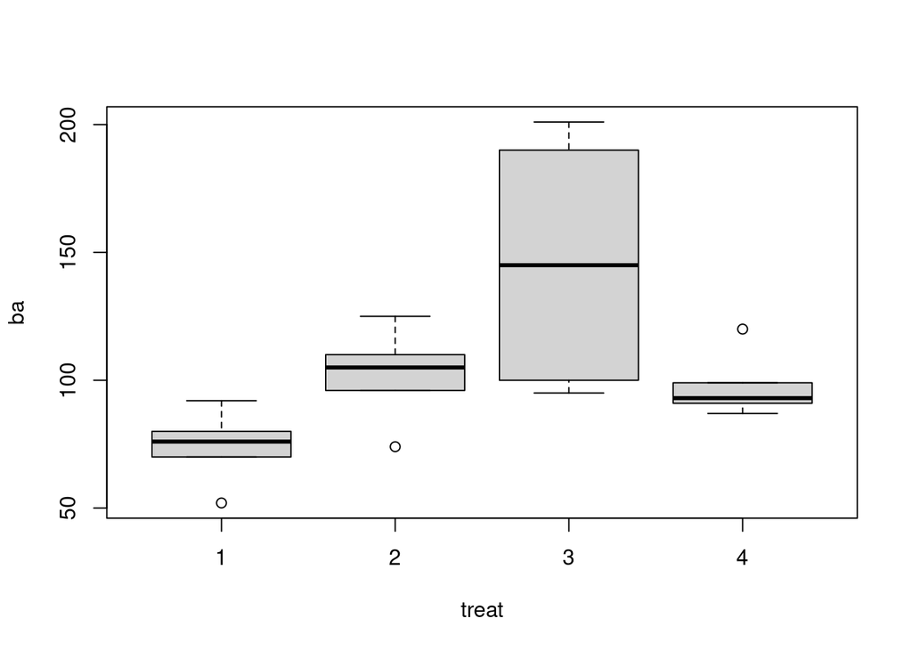

```r
treat <- factor(rep(1:4, rep(5, 4)))
ba <- c(76, 52, 92, 80, 70, 110, 96, 74, 105,
        125, 95, 145, 100, 190, 201, 87, 93, 91, 120 ,99)

boxplot(ba ~ treat)
```

```r
hangovers <- aov(ba ~ treat)
summary(hangovers)
```

```
##             Df Sum Sq Mean Sq F value  Pr(>F)
## treat        3  13582    4527   5.729 0.00736 **
## Residuals   16  12645     790
## ---
## Signif. codes:  0 '***' 0.001 '**' 0.01 '*' 0.05 '.' 0.1 ' ' 1
```

```r
library(agricolae)

# Tukey's HSD:

lsd <- HSD.test(hangovers, "treat", console = T)
```

```
##
## Study: hangovers ~ "treat"
##
## HSD Test for ba
##
## Mean Square Error:  790.3
##
## treat,  means
##
##      ba      std r Min Max
## 1  74.0 14.69694 5  52  92
## 2 102.0 18.85471 5  74 125
## 3 146.2 49.19045 5  95 201
## 4  98.0 13.03840 5  87 120
##
## Alpha: 0.05 ; DF Error: 16
## Critical Value of Studentized Range: 4.046093
##
## Minimun Significant Difference: 50.86826
##
## Treatments with the same letter are not significantly different.
##
##      ba groups
## 3 146.2      a
## 2 102.0     ab
## 4  98.0     ab
## 1  74.0      b
```

## 3.4 Multiple Comparison Tests using Student-Newman-Keuls (SNK)

The SNK test takes into consideration the number of treatments, arranged in rank order, over which a pair of treatments is being compared; the difference needed for significance for two treatment means which are ranked side by side is different from the difference needed for two means which have other treatments in between them in the rank order.

The SNK test is essentially the same as the THSD except it uses a different $q$ value depending on the range of treatment means involved instead of a fixed $k$, representing the total number of treatments.

It is known as a **MULTIPLE RANGE TEST**.

Other multiple range tests such as Duncan’s Multiple Range Test, which is used in agricultural research, are also available.

The SNK is **less conservative** than Tukey’s test - i.e. it is less likely to accept $H_0$ when it should reject it.

The SNK is **more conservative** than the t- test - i.e. it is more likely to accept $H_0$ when it should reject it.

### 3.4.1 The Procedure

#### **Step 1**

An analysis of variance (ANOVA) is carried out to test the standard hypotheses that the treatment means are all equal – see Section 1.

$$\begin{align}
H_0 & : \mu_1 = \mu_2 = \ldots = \mu_k & &
\textit{treatment means are all equal}\\
H_1 & : \mu_i \neq \mu_j \text{ for some } (i, j), i \neq j &
& \textit{treatment means are not all equal}
\end{align}$$

Test the Variance Ratio using the F-test – a global test.

**If H0 is accepted**, i.e. the means are not significantly different, then **STOP**.

**If H0 is rejected** proceed to some form of multiple comparison testing to identify which treatment means are different to each other.

#### **Step 2**

If the null hypothesis is rejected using the global test in the ANOVA then proceed with pair-wise comparisons of the means.

Calculate the standard error of a mean as: $SE_{\bar{X}} = \frac{s}{\sqrt{n}}$, where s = Root MSE in the ANOVA and n is the number of replicates in the treatment.

From the Studentised Range, $q$ tables, Table B5 in Zar and as in handout, find the Studentised Significant Ranges which depend on the following four variables – note that for SNK there will be $k-1$ $q$ values to read from the table, giving $k-1$ SNK ranges:

- $\alpha$ - level of significance;
- $\nu$ - error degrees of freedom in the ANOVA table;
- $k$ - number of treatments;
- $p$ - the number of means in rank order (smallest to largest) between and including the two means to be compared.

Note that $p$ = 2 when the means are adjacent, $p$ = 3 if there is one mean in between the two being compared, and the most extreme comparison will be between the largest and smallest means when $p$ will equal k, the number of treatments.

Calculate the SNK Least Significant Ranges:

$$\textit{SNKLSR}_{\alpha, p} =
q_{\alpha, p} \times SE_{\overline{X}}$$

Obtain a table of differences for the treatment means - see LSD procedure.

Compare the mean differences given in the table of differences with the relevant $\textit{SNKLSR}_{\alpha, p}$ values to determine the significant differences. Summarise your results clearly in written English.

### 3.4.2 Using R for the Student-Newman-Keuls Test

To carry out an SNK test we include the `agricolae` library (if it isn’t already attached from a previous analysis) and use the `SNK.test()` function on the fitted `aov()` model.

#### Example 18: Antidotes using the SNK Test – By Hand and R

From the ANOVA we had a significant $F$-test ($p$ = 0.0074). The error mean square was 790.3 giving the best estimate of the standard deviation as:$s = \sqrt{790.3} = 28.11$.

There were five replicates of each treatment so the standard error of a treatment mean is:

$$\textit{SE}_{\bar{X}}=
\frac{s}{\sqrt{n}} = \frac{28.11}{\sqrt{5}} = 12.57$$

Using $\alpha$ of 0.05, error degrees of freedom, $\nu$ = 16 (from the ANOVA), and a $k$ (number of treatments) of 4, the critical values or SSR’s from the $q$ table are found to be:

| p | 2 | 3 | 4 |
| --- | --- | --- | --- |
| $q$ or SSR | 2.998 | 3.649 | 4.046 |

An SNK Least Significant Range must be calculated for each possible $p$:

$$\textit{SNKLSR}_{\alpha, p} =
q_{\alpha, p} \times SE_{\overline{X}} = q_{\alpha, p} \times
12.57$$

| p | 2 | 3 | 4 |
| --- | --- | --- | --- |
| SNKLSR | 37.68 | 45.87 | 50.86 |

Compare these with the LSD we found using the protected t-test of: LSD = 37.69 and the THSD = 50.86.

When two adjacent means are being compared the SNK gives the same required difference as the LSD (37.68). When means at the extremes of the ranked treatments are being compared (the highest and the lowest) the SNK gives the same required difference as the THSD (50.86). For means in the middle of these extremes, the difference is between these two values.

The table of differences was found in Section 1 and is reproduced below.

$$\text{Table of Differences Between
Antidote Mean Blood Alcohol Levels}$$

|  |  | A1: Water 74.0 | A4: Potato 98.0 | A2: Milk 102.0 | A3: Onion 146.2 |
| --- | --- | --- | --- | --- | --- |
| **A3: Onion** | **146.2** | 72.2 | 48.2 | 44.2 | 0 |
| **A2: Milk** | **102.0** | 28.0 | 4.0 | 0 |  |
| **A4: Potato** | **98.0** | 24.0 | 0 |  |  |
| **A1: Water** | **74.0** | 0 |  |  |  |

When onion is compared with water, the comparison is made over all four treatments so the required difference for significance is 50.86. The difference is significant as for $t$ and Tukey.

When onion is compared with potato, the comparison is made over three treatments (note that you count the two being compared and any in between) and the required difference is 45.87. The difference of 48.2 is significant as for $t$. Recall that this difference was not significant when Tukey was used.

When onion is compared with milk the means are adjacent ($p$ =2) and the required difference is 37.68. Again, the difference is significant as it was for the $t$-test. Recall that this differences was not significant when Tukey was used.

None of the other differences in the table are as large as the smallest SNKLSR so they cannot be significant and no testing is done on them. Make sure you know which SNKLSR would be appropriate for comparing, say, milk and water.

For this example the SNK test has given exactly the same results as the protected t-test. The conservative Tukey test has, however, only detected one of the differences as significant; two of those found significant with the other tests are no longer significant.

**Using R**

The `SNK.test()` function takes the same arguments as the previous MTC functions:

```r
SNK.test(hangovers, "treat", console = T)
```

```
##
## Study: hangovers ~ "treat"
##
## Student Newman Keuls Test
## for ba
##
## Mean Square Error:  790.3
##
## treat,  means
##
##      ba      std r Min Max
## 1  74.0 14.69694 5  52  92
## 2 102.0 18.85471 5  74 125
## 3 146.2 49.19045 5  95 201
## 4  98.0 13.03840 5  87 120
##
## Alpha: 0.05 ; DF Error: 16
##
## Critical Range
##        2        3        4
## 37.69141 45.87767 50.86826
##
## Means with the same letter are not significantly different.
##
##      ba groups
## 3 146.2      a
## 2 102.0      b
## 4  98.0      b
## 1  74.0      b
```

## 3.5 The Bonferroni Test

The problem with the $t$-test is that the set level of significance applies to a single comparison of two means – this is known as a *Type I comparison error rate*. When there are a lot of such comparisons, one or more may be significant simply by chance, and there is no way of knowing this. Multiple range tests such as SNK make such an allowance and provide a control across the whole set of comparisons. This is known as an *experiment wise error rate*. What is needed is a way of controlling the experiment wise error rate, that is, the possible error **across all the paired comparisons**, when the $t$-test is used.

A simple modification to the $t$-test was proposed by Bonferroni to achieve this. To obtain a ‘reliable’ critical value for $t$, the nominated significance level is divided by the number of tests that will be carried out. For example, if four treatment means are to be compared there will be six individual tests. Recall that if a significance level of 0.05 is required, then the critical value for $p$ is 0.025 as the multiple comparisons of treatment means are two tailed $t$-tests. Therefore the probability used to obtain the ‘reliable’ critical $t$ is 0.025/6 = 0.0041666. Critical tables with such a probability are not usually available. However, the following R code will produce the required value.

```r
bonf.val <- qt(1 - (0.025/choose(4, 2)), df = 16)
bonf.val
```

```
## [1] 3.008334
```

**NOTE:** The `choose(4, 2)` function is the number of pairs of tests you can have with 4 treaments (6) and `df =` is the error DF for your anova (16 in this example code). For the above example the critical value of $T$ is 3.008.

### 3.5.1 Using R for the Bonferroni Test

To carry out a Bonferroni test we use the `LSD.test()` function from the `agricolae` library with a special argument: `p.adj = “bonferroni”` since the Bonferroni test is just an adjusted version of the LSD.

#### Example 19. Antidotes and the Bonferroni Test

Consider again the Antidote example. The Bonferroni test will not be done by hand but you should make sure that you know how to find the critical $t$ value used by R below.

```r
LSD.test(hangovers, "treat", p.adj = "bonferroni", console = T)
```

```
##
## Study: hangovers ~ "treat"
##
## LSD t Test for ba
## P value adjustment method: bonferroni
##
## Mean Square Error:  790.3
##
## treat,  means and individual ( 95 %) CI
##
##      ba      std r       LCL      UCL Min Max
## 1  74.0 14.69694 5  47.34814 100.6519  52  92
## 2 102.0 18.85471 5  75.34814 128.6519  74 125
## 3 146.2 49.19045 5 119.54814 172.8519  95 201
## 4  98.0 13.03840 5  71.34814 124.6519  87 120
##
## Alpha: 0.05 ; DF Error: 16
## Critical Value of t: 3.008334
##
## Minimum Significant Difference: 53.48747
##
## Treatments with the same letter are not significantly different.
##
##      ba groups
## 3 146.2      a
## 2 102.0     ab
## 4  98.0     ab
## 1  74.0      b
```

## 3.6 Comparing t, Tukey’s HSD, SNK and Bonferroni Tests

The following example details all four multiple comparison tests and explores their differences.

#### Example 20. Water Quality

A study has been carried out to determine the strontium concentration (mg/ml) in six different bodies of water - it is suspected that this pollutant may become a problem in the future and a base line set of data is required. The results are given below. Note that the names of the water bodies have been altered to protect the innocent.

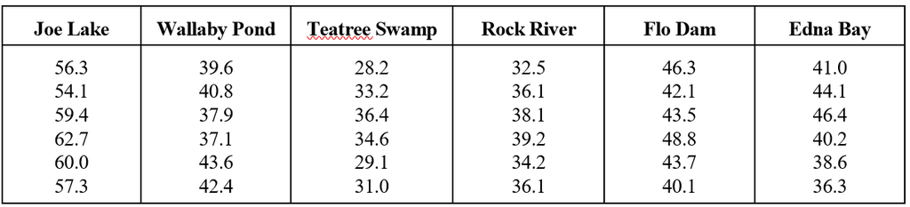

**ANOVA - calculation of Sums of Squares**

$$\begin{align}
\textbf{CF: } && (1511)^2/36 & = 63420.027 \\
\textbf{Tot SS: } && 66141.7 - \text{CF} &= 2721.672
\\
\textbf{Treat SS: } && 65867.41667 - \text{CF} & =
2447.388\\
\textbf{Error SS: } && \text{Tot SS - Treat SS} & = 274.283
\end{align}$$

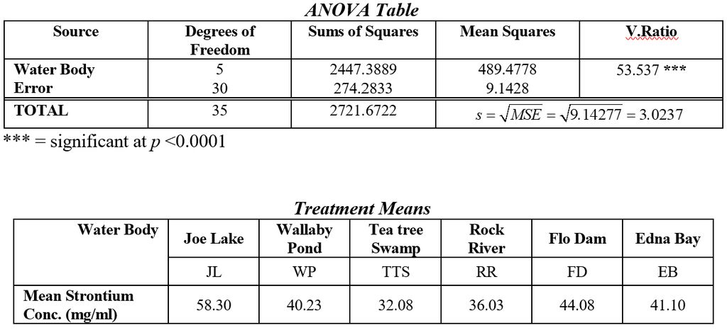

The following is the table of mean differences for the lake data:

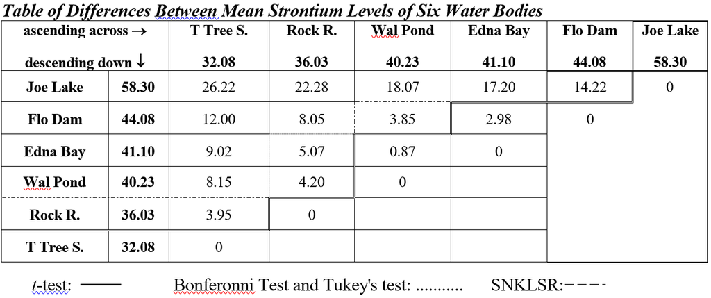

##### **$t$-test (LSD):**

Using: Zar Table B3, $\alpha = 0.05$, $\nu = 30$

$$\text{SE}_{\bar{X}_i - \bar{X}_j} = s \times \sqrt{\frac{1}{n_i} +
\frac{1}{n_j}} = \sqrt{9.1428} \times \sqrt{\frac{1}{6} + \frac{1}{6}} =
1.7457$$

$$\textbf{LSD} = \text{SE}_{\bar{X}_i - \bar{X}_j} \times t_{30}(0.025) =
1.7457 \times 2.042= \textbf{3.565}$$

(See significant differences using the $t$-test below.)

##### **Tukey’s HSD:**

Using: Zar Table B5, $\alpha = 0.05$, $\nu = 30$

$$\textit{SE}_{\bar{X}}=
\frac{s}{\sqrt{n}} = \frac{\sqrt{9.1428}}{\sqrt{6}} = 1.234$$

$$\textbf{THSD} = \text{SE}_{\bar{X}} \times q_{30, 6} = 1.234 \times
4.302 = \textbf{5.309}$$

(See significant differences using Tukey’s HSD below.)

##### **SNKLSR:**

Using: Zar Table B5, $\alpha = 0.05$, $\nu = 30$

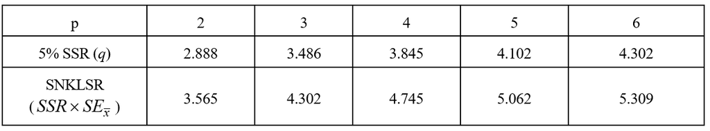

(See significant differences using SNKLSR below.)

- To compare Joe Lake with Tea Tree Swamp we must compare across all 6 means in the ranked order - Joe Lake is 1, then FD, EB, WP and RR and finally TTS making a total of six. Thus the least difference needed between these two means is found under $p$ = 6, i.e 5.309.
- To compare Joe Lake with Rock River we must compare across FD, EB and WP (3) making a total of five when Joe Lake and Rock River are included. This means the least difference needed between these two means is found under the $p$ = 5, i.e 5.062.
- When two adjacent means are compared, eg Flo Dam and Edna Bay, we need $p$ = 2 and a difference of 3.565. This will be the same for comparing JL and FD, FD and EB, EB and WP, WP and RR and RR and TTS as all of these involve adjacent comparisons.
- For Wallaby Pond versus Tea Tree Swamp, we move from WP over RR to TTS giving a total of three means in the span; thus $p$ = 3 and the SNKLSR = 4.302.
- Comparisons across a span of 4 will occur for JL versus WP, for FD versus RR and for EB versus TTS; each of these will need to be 4.745 different to reach significance.

##### **Bonferonni Adjusted LSD:**

There are six treatment means to be compared, which totals 15 comparisons in all: $\alpha = 0.05/15 = 0.003333$. Since this is a 2-tailed test we need the critical $t$ with 30 df that gives a cut off probability of 0.00167 (0.003333/2 = 0.00167). We can use R to find this critical value:

```r
qt(1 - (0.025/choose(6, 2)), df = 30)
```

```
## [1] 3.188806
```

Now we simply recalculate the LSD value from above using the Bonferonni adjusted critical $t$ (ie the only thing that changes in the LSD calculation is the value of $t$):

$$\textbf{BLSD} = \text{SE}_{\bar{X}_i - \bar{X}_j} \times t_{30}(0.00167)
= 1.7457 \times 3.1888= \textbf{5.565}$$

(See significant differences using the Bonferonni adjusted LSD below.)

##### **Significant Differences:**

Refer to Table of Mean Differences above.

###### **(a) Using $t$-test (LSD):**

Differences between means will be significant if they exceed 3.565.

- Joe Lake $\neq$ all others
- Flo Dam $\neq$ T Tree S., Rock River, Wal Pond
- Edna Bay $\neq$ T Tree S., Rock River
- Wal Pond $\neq$ T Tree S., Rock River
- Rock River $\neq$ T Tree S.
- T Tree S. $\neq$ all others

###### **(b) Using Tukey’s HSD:**

Differences between means will be significant if they exceed 5.309.

- Joe Lake $\neq$ all others
- Flo Dam $\neq$ T Tree S., Rock River
- Edna Bay $\neq$ T Tree S.
- Wal Pond $\neq$ T Tree S.
- Rock River $\neq$ Joe Lake, Flo Dam
- T Tree S. $\neq$ Joe Lake, Flo Dam, Edna Bay, Wal Pond

###### **(c) Using SNKLSR:**

Differences between means will be significant if they exceed the critical value obtained from SNKLSR table above (Section SNKLSR), which varies according to how many treatments are being compared across.

- Joe Lake $\neq$ all others
- Flo Dam $\neq$ T Tree S., Rock River
- Edna Bay $\neq$ T Tree S., Rock River
- Wal Pond $\neq$ T Tree S., Rock River
- Rock River $\neq$ all others
- T Tree S. $\neq$ all others

The *Significant Differences* are a mixture of those found for the $t$-test, Tukey test and Bonferonni test. Compare them and be sure you understand the meaning of the ‘conservative’ natures of the 3 tests. Note that when adjacent means are compared the SNKLSR is the same as the LSD; when the most extreme comparison is made (largest versus smallest means) the SNKLSR is the same as the THSD. English interpretations will vary accordingly.

###### **(d) Using Bonferonni Adjusted LSD:**

Differences between means will be significant if they exceed 5.565.

- Joe Lake $\neq$ all others
- Flo Dam $\neq$ T Tree S., Rock River
- Edna Bay $\neq$ T Tree S.
- Wal Pond $\neq$ T Tree S.
- Rock River $\neq$ Joe Lake, Flo Dam
- T Tree S. $\neq$ Joe Lake, Flo Dam, Edna Bay, Wal Pond

*Results are the same as Tukey’s*

##### **English Interpretation**

###### **Using $t$-test**

The mean strontium levels in the six water bodies were found to vary significantly ($p$ < 0.05). The mean strontium concentration in Joe Lake (58.30), Rock River (36.03) and Tea Tree Swamp (32.08) were significantly different from the mean strontium concentrations in all other water bodies ($p$ < 0.05), with Joe Lake being at the upper end and Rock River and Tea Tree Swamp at the lower end of the range of means. The mean strontium concentration in Flo Dam (44.08) was significantly different ($p$ < 0.05) from Tea Tree Swamp (32.08), Rock River (36.03), Wallaby Pond (40.23) and Joe Lake (58.30). The mean strontium concentration in Edna Bay (41.10) was significantly different ($p$ < 0.05) from Tea Tree Swamp (32.08), Rock River (36.03) and Joe Lake (58.30). The mean strontium concentration in Wallaby Pond (40.23) was significantly different ($p$ < 0.05) from Tea Tree Swamp (32.08), Rock River (36.03), Flo Dam (44.08) and Joe Lake (58.30).

###### **Using Tukey’s HSD or Bonferonni Adjusted LSD**

The mean strontium levels in the six water bodies were found to vary significantly ($p$ < 0.05). The mean strontium concentration in Joe Lake (58.30) was significantly different from the mean strontium concentrations in all other water bodies ($p$ < 0.05). The mean strontium level in Tea Tree Swamp (32.08) was significantly different from the mean levels in all other bodies except Rock River (36.03) and appeared to be lower ($p$ < 0.05). The mean strontium concentration in Flo’s Dam, Edna Bay and Wallaby pond (44.08, 41.10 and 40.23 respectively) were similar and were all significantly different from the mean concentration in Tea Tree Swamp (32.08; $p$ < 0.05). Flo Dam appeared to have a mean strontium concentration which was significantly different from that found in the Rock River (44.08 v 36.03; $p$ < 0.05). However, in this sample of data, Edna Bay, Wallaby Pond and Rock River had strontium concentrations, which were not different (41.10, 40.23 and 36.03 respectively; $p \geq 0.05$).

###### **Using SNKLSR**

This is left as an exercise for you.

**NOTES**

1. The words used above are to give you a variety of ideas as to how you could report your results. In any given situation you would be unlikely to use ALL the specific comparisons - which are used **depends on the questions being asked by the research!**
2. The test you use and the subsequent conclusions depend on your own personal choice, your supervisor’s preference, the accepted norms within your discipline, and/or the journal you wish to use. See the R documentation, the agricolae library documentation, and search for various other options online if they arise in your discipline area.

James McBroom - Trimester 2, 2022

*j.mcbroom@griffith.edu.au*